# Intro to R Time Series (and a few Finance Packages)

## 4. dataframe/tibble with time series

As the [`tidyverse` eco-system](https://www.tidyverse.org/) becomes more and more popular. Developers start to bridge the gap between the traditional time series world and the `tidyverse` world. See the links below for a few examples.

1. [tissible](https://tsibble.tidyverts.org/): a new time series class (`tbl_ts`) built on `tibble`.
2. [fable](https://fable.tidyverts.org/): an extension of `forecast` package to work with `tissible`
3. [tidyquant](https://business-science.github.io/tidyquant/): “integrates the best resources for collecting and analyzing financial data, `zoo`, `xts`, `quantmod`, `TTR`, and `PerformanceAnalytics`, with the tidy data infrastructure of the `tidyverse`, allowing for seamless interaction between each.”"
4. [tibbletime](https://business-science.github.io/tibbletime/): a time-aware tibble.

[txbox](https://www.tsbox.help/) provides conversion between many time series data structures, an attempt to unite time series data structure in R.

## 5. a few more R finance packages

We have seen `forecast`, `quantmod`, and `PerformanceAnalytics` packages so far. Refer to R [taskview](https://cran.r-project.org/web/views/), in particular, [finance taskview](https://cran.r-project.org/web/views/Finance.html) and [time series taskview](https://cran.r-project.org/web/views/TimeSeries.html) for an overview on what R has to offer for financial analysis. Below are a brief intro to `quantmod` and `RQuantLib` packages.

### 5.1 quantmod

[quantmod](http://www.quantmod.com/) is an R package designed to assist quantitative traders in “development, testing, and deployment of statistically based trading models.” We will take a quick look at it.

```r
library(quantmod)

# get MSFT OHLC data from yahoo
getSymbols("MSFT", src="yahoo")
```

```
## [1] "MSFT"
```

```r
# display a few row of MSFT dataset
head(MSFT)
```

```
##            MSFT.Open MSFT.High MSFT.Low MSFT.Close MSFT.Volume
## 2007-01-03     29.91     30.25    29.40      29.86    76935100
## 2007-01-04     29.70     29.97    29.44      29.81    45774500
## 2007-01-05     29.63     29.75    29.45      29.64    44607200
## 2007-01-08     29.65     30.10    29.53      29.93    50220200
## 2007-01-09     30.00     30.18    29.73      29.96    44636600
## 2007-01-10     29.80     29.89    29.43      29.66    55017400
##            MSFT.Adjusted
## 2007-01-03      22.18531
## 2007-01-04      22.14815
## 2007-01-05      22.02185
## 2007-01-08      22.23731
## 2007-01-09      22.25961
## 2007-01-10      22.03671
```

```r
# check its data structure
str(MSFT)
```

```
## An 'xts' object on 2007-01-03/2020-02-24 containing:
##   Data: num [1:3308, 1:6] 29.9 29.7 29.6 29.6 30 ...
##  - attr(*, "dimnames")=List of 2
##   ..$ : NULL
##   ..$ : chr [1:6] "MSFT.Open" "MSFT.High" "MSFT.Low" "MSFT.Close" ...
##   Indexed by objects of class: [Date] TZ: UTC
##   xts Attributes:
## List of 2
##  $ src    : chr "yahoo"
##  $ updated: POSIXct[1:1], format: "2020-02-25 11:33:37"
```

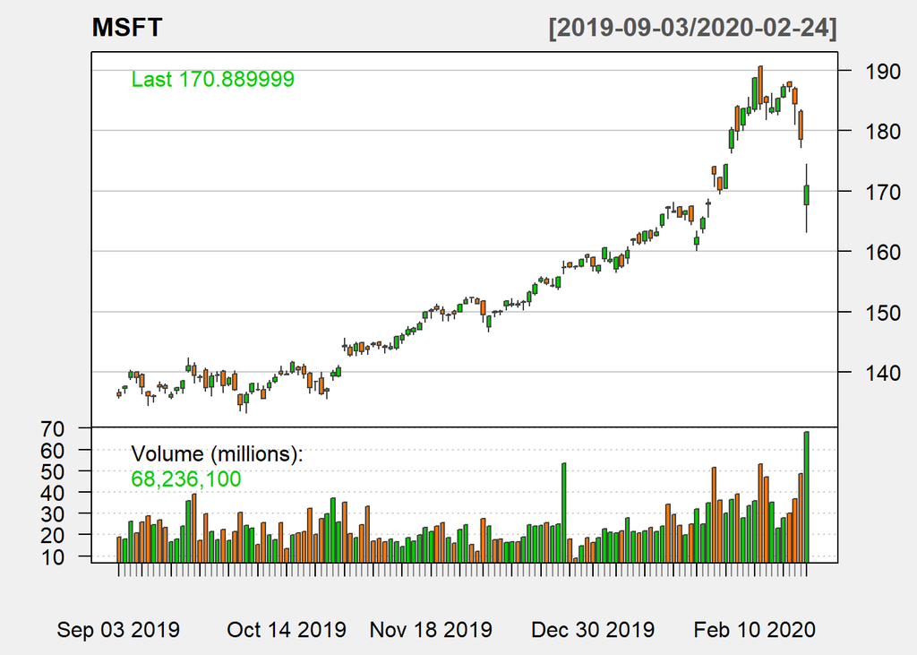

```r
# plot using the build-in chartSeries() function
chartSeries(MSFT, theme = chartTheme("white"), subset = "last 6 months")
```

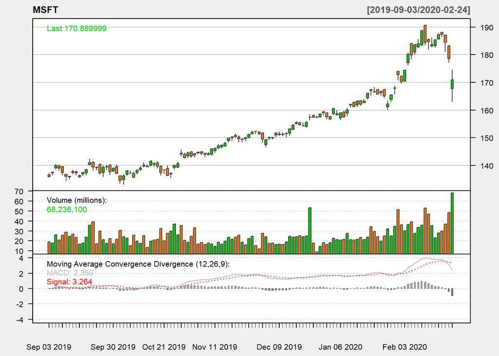

```r
# add MACD plot, https://en.wikipedia.org/wiki/MACD
addMACD()
```

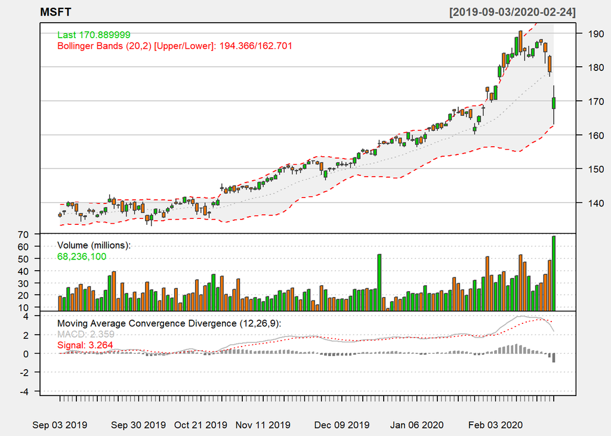

```r
# add Bollinger bands, https://en.wikipedia.org/wiki/Bollinger_Bands
addBBands()
```

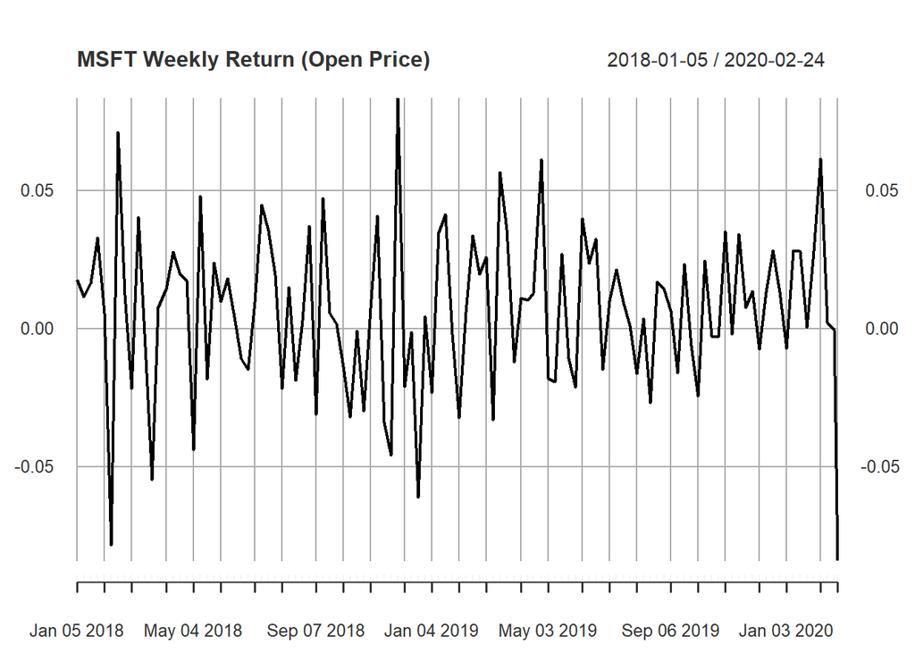

```r
# plot the weekly return using plot() function, open price
plot(weeklyReturn(MSFT['2018-01::', 'MSFT.Open']), main = "MSFT Weekly Return (Open Price)")
```

`weeklyReturn(MSFT['2018-01::'])` returns an `xts` object, `ggplot()` can handle it too.

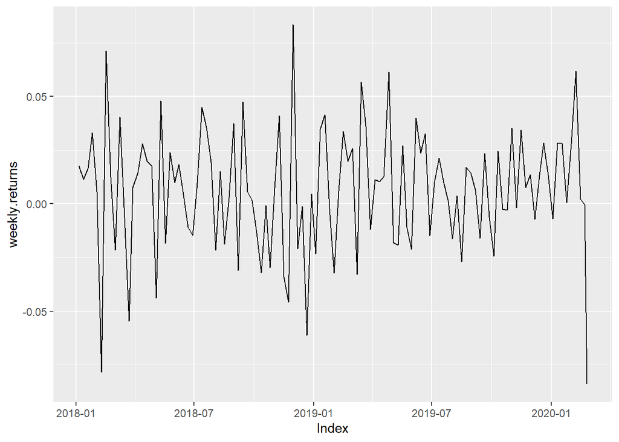

```r
# plot the weekly returns using ggplot()
library(ggplot2)
ggplot(weeklyReturn(MSFT['2018-01::', 'MSFT.Open']), aes(x = Index, y = weekly.returns)) +
  geom_line()
```

### 5.2 RQuantLib

[QuantLib](https://www.quantlib.org/) is a comprehensive free/open-source library for quantitative finance. [RQuantLib](http://dirk.eddelbuettel.com/code/rquantlib.html) makes part of QuantLib accessible from R (i.e. RQuantLib is an R interface to QuantLib). It provides many functions for option pricing and fixed income. It also provides a few utility functions (such as `isHoliday()`, `isWeekend()`, etc.).

Let’s try a few functions in `RQuantLib` package.

```r
library(RQuantLib)

# European Option pricing based on BS formula
# EuropeanOption(type, underlying, strike, dividendYield,
#                riskFreeRate, maturity, volatility, discreteDividends,
#                discreteDividendsTimeUntil)
EO <- EuropeanOption("call", 100, 100, 0.01, 0.03, 0.5, 0.4)
EO
```

```
## Concise summary of valuation for EuropeanOption
##    value    delta    gamma     vega    theta      rho   divRho
##  11.6365   0.5673   0.0138  27.6336 -11.8390  22.5475 -28.3657
```

```r
# calculate European Option Implied Volatility
# EuropeanOptionImpliedVolatility(type, value, underlying, strike, dividendYield,
#                                 riskFreeRate, maturity, volatility)
# note: the volatility argument is the Initial guess for the volatility of the underlying stock
EOImpVol <- EuropeanOptionImpliedVolatility("call", value=EO$value+0.50, 100, 100, 0.01, 0.03, 0.5, 0.4)
EOImpVol
```

```
## [1] 0.4181015
## attr(,"class")
## [1] "EuropeanOptionImpliedVolatility" "ImpliedVolatility"
```

```r
isHoliday(calendar = "Canada", dates = as.Date("2019-07-01"))
```

```
## [1] TRUE
```

```r
isHoliday(calendar = "UnitedStates", dates = as.Date("2019-07-01"))
```

```
## [1] FALSE
```

## References

1. [Using R for Time Series Analysis](https://a-little-book-of-r-for-time-series.readthedocs.io/en/latest/src/timeseries.html) from [a Little Book of R for Time Series](https://a-little-book-of-r-for-time-series.readthedocs.io/en/latest/index.html).
2. [Forecasting: Principles and Practice](https://otexts.com/fpp2/)
3. Daniel Lee’s [Financial Modeling](https://rpubs.com/DanielSLee/IntroPortfolioAnalysis)